# TopiKhan (topic modeling + Khan Academy)

## *Exploring the topic space of Khan Academy videos to make learning more efficient*

The overarching goal of this project is improve the efficiency of learning from Khan Academy videos. Our primary approach is to derive a 'knowledge profile' for each video/course-- a quantitative summary of the content present in the course derived from [linguistic models](http://www.cs.columbia.edu/~blei/papers/BleiNgJordan2003.pdf) applied to the course transcripts. Then, we’ll derive a 'knowledge fingerprint' for the learner, i.e. an estimate of the student’s current knowledge state based on quiz performance. Finally, we integrate these models to create algorithms that adapt the trajectory of a course to minimize the time it takes for a student to reach a 'target' knowledge profile. Below is a brief overview of some highlights from the project so far.

## Load in the libraries we need

```python
import hypertools as hyp
import numpy as np
import pandas as pd
import seaborn as sns
import matplotlib.pyplot as plt
%matplotlib inline
```

## Load in the topic models

Using the the Khan Academy and Youtube API, I downloaded course transcripts for as many videos as I could. For each course, I concatenated the transcripts, and fit a [topic model](http://scikit-learn.org/stable/modules/generated/sklearn.decomposition.LatentDirichletAllocation.html) to each course. The result is a courses (4128) by topics (100) matrix, where each row is a vector of topic weights for each Khan Academy course. The colors represent the weights for each topic (i.e. how much of a particular topic was present in the course).

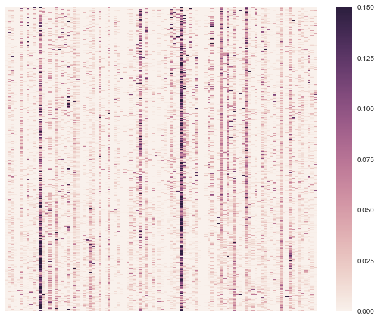

```python
data = np.load('Khan Academy.npy')
plt.figure(figsize=(10, 8))
ax = sns.heatmap(data, xticklabels=False, yticklabels=False, vmin=0, vmax=.15)
```

In the plot above, it appears that some topics are consistently found across all courses, while others seem to vary by course. Below I will read in some course labels that were extracted from the Khan Academy API.

```python
text_file = open("parents.txt", "r")
lines = text_file.read().split('\n')

group=[]
for line in lines:
    if len(line.split('/'))>=2:
        group.append(line.split('/')[2])
    else:
        pass
```

### Plot the topic models for each course using Hypertools

High dimensional data are difficult to visualize. To deal with this, we developed a [toolbox](https://github.com/ContextLab/hypertools) for high-dimensional data visualization and manipulation. The toolbox uses dimensionality reduction (specifically, principal components analysis) to embed high-dimensional data in a lower dimensional space, and we're expanding it to support other dimensionality reduction approaches.

Below, I'm plotting the topic model for each course as a 3D point (i.e. the first 3 principal components for the course as a coordinate), colored by the field of study. This will help us get a sense as to whether the the topics models are structured with respect to the kind of information that is being presented in the video. For example, you might expect the topic models for math courses to be more similar to each other than to say, an Arts and humanities course.

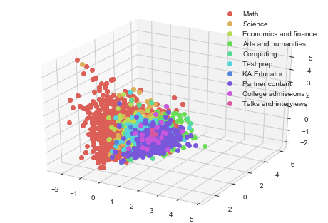

```python
legend = list(sorted(set(group), key=group.index))
hyp.plot(data,'o', group=group, legend=legend)
```

Interestingly, there is definitely structure in the plot above: courses that are conceptually similar to each other have more similar topic models. Another (perhaps, coarser) way to visualize this structure is to look at the correlation matrix for the fields of study. Below, I'm computing the average topic model for all courses in a given field, and then correlating those averaged topic vector over each field of study. This correlation matrix represents the similarity of each field of study to other fields of study.

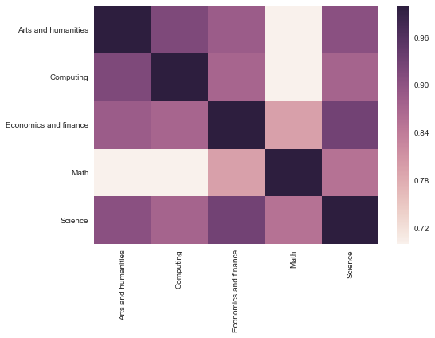

```python
df = pd.DataFrame(data, index=group)
data_corr = df.groupby(df.index).mean().ix[['Arts and humanities', 'Computing', 'Economics and finance', 'Math', 'Science'],:].T.corr()
a = sns.heatmap(data_corr, vmin=.7, vmax=1)
plt.yticks(rotation=0)
plt.xticks(rotation=90)
plt.show()
```

Interestingly, viewing the data through this lens suggests that math courses are least similar to the other fields of study. Another way to visualize this is to use multi-dimensional scaling to create a 3D plot that retains the pairwise relationships between the fields of study. To do this we'll use scikit-learn's MDS function, and feed that into hypertools to add labels.

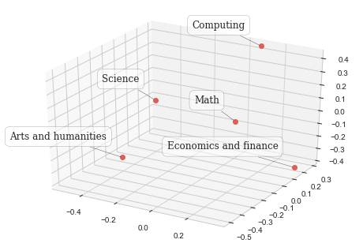

```python
from sklearn.manifold import MDS

m = MDS(n_components=3, dissimilarity='precomputed')
reduced_data = m.fit_transform(data_corr)
hyp.plot(reduced_data, 'o', labels=['Arts and humanities', 'Computing', 'Economics and finance', 'Math', 'Science'])
```

Next we'll zoom into a single field and take a closer look a the local structure. In previous analyses, I found that science courses have a neat clustering structure so we'll use that field as an example. Below, I'll select only the science courses, and color the points by the subfield (i.e. biology, physics, chemistry etc).

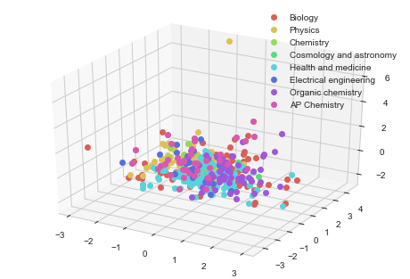

```python
science_courses = [(i,j.split('/')[3]) for i,j,k in zip(data,lines,group) if k=='Science']
science_data = np.array([i[0] for i in science_courses])
science_group = [i[1] for i in science_courses]
science_legend = list(sorted(set(science_group), key=science_group.index))
hyp.plot(science_data,'o', group=science_group, legend=science_legend)
```

At first glance, the structure is not readily noticeable. However, a small tweak to the data matrix reveals some really interesting clustering. Hypertools has a built-in simple way to normalize features. Specifically, I'll z-score the columns (topics) of the matrix. Doing this makes the weights for a particular topic across all science courses relative to other courses in the set (only science courses as opposed to all over Khan courses). When we do this, some beautiful structure emerges:

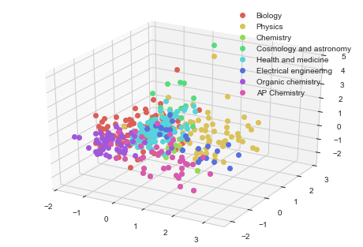

```python
hyp.plot(science_data,'o', group=science_group, legend=science_legend, normalize='within')
```

Now, it's much easier to see that courses within the same subfield seem to cluster together. We can use the cluster feature of Hypertools to ask whether these clusters can be emprically recovered. Internally, Hypertools uses k-means clustering to find clusters in the data given n_clusters (k).

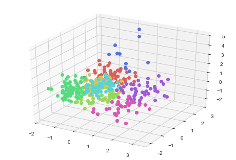

```python
hyp.plot(science_data,'o', normalize='within', n_clusters=8)
```

While not perfect, the unsupervised clustering seems to roughly correspond to the clustering as colored by subfield label. Lastly, we can play the same game as above and plot the science correlation matrix and MDS plot.

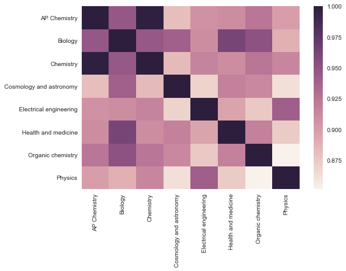

```python
df = pd.DataFrame(science_data, index=science_group)
science_data_corr = df.groupby(df.index).mean().T.corr()
g = sns.heatmap(science_data_corr)
plt.yticks(rotation=0)
plt.xticks(rotation=90)
plt.show()
```

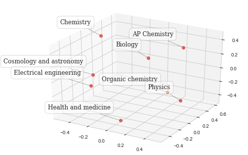

```python
m = MDS(n_components=3, dissimilarity='precomputed')
reduced_science_data = m.fit_transform(science_data_corr)
hyp.plot(reduced_science_data, 'o', labels=list(science_data_corr.columns.values))
```

## Closing thoughts

While the above analyses are interesting, this is really only the tip of the iceberg. I'm also beginning to explore other related questions, such as:

1) **Does the "scope" of the topic model used change the similarity structure among courses/fields of study?** For example, does a topic model trained on many Wikipedia articles vs. only Khan Academy videos make everything look more similar? Likewise, does a topic model trained on a subfield distort the global similarity structure, emphasizing similarity in some dimensions over others?

2) **Can we use dynamic topic models to capture the "trajectory" of a given course through "topic space"?** For instance, if we break each video into smaller chunks and estimate topic models for each chunk, can we plot the path that the course travels? Do courses revisit topics in some structured way, and does this relate to the "quality" of the course? Do different students prefer different trajectory structures, and could this be used to personalize the selection of educational materials for the student?

While the structure described above is interesting in of itself, my greater hope is that these techniques may be used to improve personalized learning algorithms. In the same way that one can create a topic model for a particular video/course, it is also possible to model student knowledge as a vector of weights representing a student's proficiency with respect to a particular topic. Combining these two techniques has the potential to drastically improve personalized learning.

For example, if you can estimate a student's "knowledge fingerprint" (i.e. vector of weights representing topic knowledge), then you can make inferences about their likely performance on any other course by comparing the student's fingerprint to the topic vector for that course. This could be used to create adaptive learning programs that maximize the potential for learning on any given course, or custom automated video curations that teach a combination of skills.

## Using content modeling to personalize and optimize learning

Below is a rough outline of how this could all fit together. Topic modelling could be used to infer the content of courses and quiz questions by modelling the transcripts and quiz text, respectively. It's then possible to estimate a student's "knowledge fingerprint" by leveraging their performance on the quiz. The more questions answered, the better the model of the student's knowledge state. Finally, one can select future educational materials to maximize the potential for knowledge gain with respect to a 'target' knowledge state.

[figure not shown]